# Nova nekropola

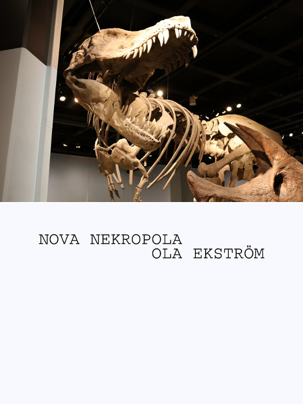

*Till Helena*

Nova nekropola  
av K. Ola Ekström  
CC BY-SA  
omslagsfoto av författaren; fossil av Tyrannosaurus Rex, Naturhistoriska Riksmuseet, Stockholm

Drömland Media 2019  
dromland.se  
ISBN 978-91-981968-2-5

Källa: https://archive.org/details/ola_ekstrom_-_nova_nekropola

## ?

Tiden är en tvåhövdad tupp  
ena huvudet är vänt mot söder  
det andra mot sydsydväst

## Inspärrad

Kackerlackorna stirrar på mig ur vrårna i cellen  
Väntar på att jag ska bli galen  
så de kan äta upp mig

## Mannen i det höga slottet

Genom teleskopet på min månbas  
tittar jag ner på en flock bajsande hyenor  
I makt av kung över de tomma korridorerna  
avsätter jag mig själv

Mitt politiska system är ofelbart  
Kaos utbryter när det generella intellektet får råda  
Vacuumet är rädd för att komma in till mig

## ?

Profeter klädda i trasor  
drar omkring på stadens gator  
skanderandes ”– Det dunkelt sagda är det dunkelt tänkta!”  
Misshandlar alla som opponerar sig

## Skynda fynda

Hittade min hjärna inlagd i sprit i en lagerlokal idag  
Undrade just vart den blev av  
Jag hade tur att de inte gjorde ströbröd av den

Den kunde blivit mat  
åt änderna i ån  
Hur skulle jag då  
kunnat sätta ihop alla bitar?

## Blues

En kvinna med båda armarna och båda benen amputerade satt i en tvättkorg på bardisken. Hon sa:

”– En dag nere vid majsfälten såg jag en armé av trädgårdstomtar komma marscherande mot mig. Det finns inte tillräckligt med whisky i hela världen för att glömma den synen!”

Vid stängningsdags brukade man turas om att bära hem henne.

## When fat mama sings

Svart natt  
vit spindel  
med ben av åska

## Fabel 140622

En elefant går förbi  
en vandaliserad telefonkiosk  
på savannen  
På dess tak knaprar en gam  
på rostad fingerborgsblomma  
Det är mitt på dagen  
och solen gassar

[scenbyte]

Fyrvaktaren matar måsarna  
med nedskrivna trupprörelser  
Snart blir det regn

## Dystopia okej (En strålande framtid)

Strålsjuka bävrar  
biter kuken av polischefen  
i Robotstaden  
(som en slags protest)  
Anmäler sig sedan frivilligt  
för slutförvaring  
enligt traditionen

## 6 juni

Arvet av Tegnér, Geijer och Heidenstam  
dras av ett spann ejakulerande hingstar  
genom ett brinnande dike fyllt av träck

Mals med minnen och stolthet  
under Samsaras snurrande hjul  
till aska i glömskans vind

## Ett hus byggt på sand

Vid strandkanten  
i den mjuka vinden från havet  
ser rättsläkaren sina händer åldras  
Ansikten av vax smälter  
i solnedgången  
Den gamla havssköldpaddan  
återvänder till havet  
utan att se sig om

## Hulterstad Bound - ode till urskogen

(Lämna ert bagage  
vid porten utan port  
för ökad klarhet)

Ut ur det vilda stiger de  
en efter en  
svartklädda och kottkränkta  
med fullständig källarlicens

Pappegojfria drömvyer  
och actionfärg – voilà!

Tillbaka från en tredagars simtur  
låter vi oss fångas i ett torrjuck  
natt och dag  
och renar oss i subbas och kommunpolitik

## November

På kullen ovanför stranden  
blåser en iskall vind i torrt gräs  
En räv tittar ut över vattnet  
och på den grå himlen

Nere vid strandkanten  
stryker en hungrig katt omkring  
”– Det är som det är” tänker räven

## Början till slutet

Flickan vid busstationen  
strimlar sitt pass med mattkniv  
Matar herrelösa hundar  
med biometrisk information

Det är sen eftermiddag  
och på motorvägen intill  
har rusningstrafiken precis kommit igång  
Människor är på väg hem  
i solnedgången och smogen  
för att aldrig återvända

Bit för bit  
raderas motorvägen från kartan

## Alternativa fakta

Jorden är som ni kanske känner till ihålig  
Där inne sitter Hitler i en apbur och runkar  
Illuminati garvar sig harmynta  
åt hur de lyckades fejka månlandningarna  
och staten tillsätter kräkmedel i spriten på Systembolaget  
Som alla vet

## Undergången är nära

Var hälsade, långväga bröder och systrar

Jag skriver till er i de sista av dagar  
Tecknen är många:  
Britney är skallig  
Samsung imploderar  
Snorlax vrider sig i sin slummer

Min levnad är snart över, min fåfänga lever vidare

## Dökött

Döda kroppar stockar sig under bron  
kontemplerar ormens essens

Jag vill inte dröja vid detaljer  
flyter hellre med strömmen  
På samma gång en del av det hela  
är jag också en enhet  
och rör mig obehindrat  
mellan olika verkligheter

Ställd inför två dåliga alternativ  
väljer jag ett tredje

## Détournement

Vi driver planlöst genom den rätvinkliga staden  
av glas och betong  
Solen blänker i våra hjässor  
och vinden smeker våra skägg  
Arkitekterna står ingenstans att finna

Folktomma katedraler slumrar  
till minnet av ostoppbar tillväxt  
Se där! – den stora handelsplatsen  
fordom sjudande av liv

Men dess död är en chimär  
då skuggor skyndar över väggarna  
Auror av tjur och björn flyger genom salen  
snabbare än tanken

Lekfullt väljer vi en annan väg  
och lämnar scenen  
I en udda vinkel passerar vi ut  
genom stenväggen  
som pianotråd genom ost

## Mannen utan minne

En man utan minne,  
en sådan man är jag  
Här ena stunden  
borta nästa

Snöflingor i vattenpölen  
Vem är jag nu?

## Kollektiv kuvös

Mjukt ljus i guld och grönt  
Nakna kryper vi ner  
i våra celler i födslokammaren

Ett par veckor  
i stillhet och gelé  
och vi träder alla fram  
som mördarbidrottningar

## Avbrott

Två människor står i ett rum  
(båda bär slips)  
De har grälat, varit djupt oense  
Till slut uppstod en tystnad  
när alla argument upprepats flera gånger  
och tröttheten lagt sordin över vreden

Då knallar en sköldpadda fram under soffan

”– God afton medborgare, säger sköldpaddan.  
Jag är en uråldrig budbärare från pyramiderna.  
Jag ska straxt bibringa er stor visdom,  
men först måste vi tala om parallella universum.”

Här kollapsar verkligheten  
under tyngden av sina memes  
och blir till ett vitt hål.

Lycka till.

## ?

Vampyrer på skateboards  
bär hjälm

## Mina omgivningar

Jag bor i ett hål i marken  
När det regnar har jag vatten till anklarna  
På vintern fryser jag fast

## Oraklet i sanden

Hittade en ny vän begravd på stranden  
En uppblåsbar clown  
fylld med handskrivna böner från storstadshipsters  
nedtecknade med ett skiffer ingen kommer ihåg längre

Pumpad full med sanningsserum  
hade clownen många andra hemligheter att berätta

## Grå toner

En klump smält bly  
kall som is i min hand  
Jag ger den till dig  
som en gåva

## Street life

Ett spöke flyger fram genom rusningstrafiken  
På fel sida av vägen skär bilarna genom det  
utan att se det

Vid en starkt trafikerad korsning  
svänger spöket vänster och tar sikte på solnedgången  
Missar en brandbil med en hårsmån

## Trälarnas lön

En abnormitet av gjutjärn  
väser ånga i en smutsig tegelbyggnad  
Små grå fönster alldeles under taket  
Hungrig sylvass käft  
blir aldrig mätt  
Äter sömmerskor och finmekaniker dagen lång  
I motsatt ände på löpande band  
konservburkar med opiater matas ut

## Euklides can't touch this

I svartbrända träd på Lengs platå  
sitter askgrå profeter  
och berättar lögner för förbipasserande  
En kall vind  
låter inte grenarna vila

## Vattenhålet

Det finns en bar mitt i Sahara  
Där sitter kamelhövdade män vid bardisken  
och tittar på cricket

En enorm svävande ögonlob  
serverar öl och drinkar

I ett mörkt hörn  
en ensam skepnad  
Stirrar

## O broder

Vi jagade in pestbäraren  
i den gamla nedlagda kvarnen  
Därinne satt han och gnydde efter smör  
men vi var hårda  
Alla visste att han var jag

## Jag lever urbant

Min rättegång hölls i ett soprum  
men när jag kom dit var den redan över  
Domen hade fallit utan att jag fått yttra mig

Jag ser från mitt fönster att de väntar på mig  
nere på ödetomten  
Men jag har krypterat namnet på ytterdörren  
Jag kommer aldrig att vara din hund

## ?

Jag önskar att jag vore intellektuell  
De ser ut att ha så roligt

## Babel

Den nya tidens litterära kotterier  
formeras, producerar och upplöses  
inom 30 millisekunder  
Hela genrer föds och dör  
medan du blinkar

## Svartsyn

Min skugga är enorm  
Den omsluter mig  
slukar mig  
utan ögon

## Nexus 7

Han åkte fast när han urinerade vid Tannhäuserporten. U-strålarna glittrade som diamanter i det skarpa solljuset. Det gav honom en chans att tänka igenom sitt liv. Omkring 1000 år tidigare i en datasal i Linköping stod han bredvid amfetaminkännaren som lyssnade på musik i lurar.  
”– Vad lyssnar du på?” frågade han.  
”– Jungle” sa amfetaminkännaren med ett leende och satte tillbaka lurarna över öronen.  
Tiden var ett gummiband, fyllon välte parkbänkar i ån, himlen över Los Angeles brann i onaturliga färger och tulltjänstemannen sa trött:  
”– Hur lång tid ska herrn spendera hos oss?”  
”– Fyra veckor” svarade den lilla pojken.  
Kupolen på Mars hotade att spricka av oförlöst sexuell energi och det var ett par år tidigare och den ännu mindre pojken satt i en bil på motorvägen utanför Örebro och längtade efter vatten men det fanns inget på en lång stund för vägen var för komplicerad.  
”– Om ni bara kunde se vad jag sett med era ögon...” mumlade han där han låg med handfängsel i baksätet på polissvävaren och han skulle just fråga poliserna om lösenordet till wifin på Tempelhof när han kom på att det inte gick för att det inte hade hänt ännu. Ordet ”RENAR” blinkade med gul text över blå bakgrund på en monitor medan svävaren höjde sig över skyskraporna på väg till häktet.  
”– Dags att dö” sa han och slöt ögonen.

## En tankesmedja

I ett mystiskt skjul i Småland  
föder man upp drakar  
Drakarna drömmer dagen lång  
om statistiska samband  
och noder  
Oceaner av noder  
vid järnvägen

## Informationsåtervinning

Inne i biblioteket sitter en mumie bakom lånedisken.  
”– Varför är det inga böcker på hyllorna?” frågar låntagaren.  
”– Det här är den totala relativismens tidevarv” svarar mumien. ”Vi har kört alla böcker genom en stor papperstugg och har sedan slumpmässigt arrangerat alla bokstäver i en lång rad som finns att läsa på internet. Eftersom ett påstående är lika sant eller falskt som något annat är denna bokstavsgegga allt som återstår av mänsklighetens samlade vetande.”  
”– Men jag ville ju läsa *Mot fyren* av Virginia Woolf!” protesterar låntagaren.  
”– Fake news” replikerar mumien.

## Oskyldig

I en koloni på mars  
sitter en människa på marken  
och letar igenom högar av kasserade bubbelgum  
Det var inte hennes fel att kupolen sprack

Just nu hålls den ihop av en jätte  
men hur länge?  
Aldrig har stjärnorna haft så kalla ögon

## Hur år täljdes i Vadstena

Strandängen mellan Klosterkyrkan och det gamla vattentornet låg tyst och stilla. Endast ett svagt sus gick genom de gamla trädens kronor och en slö humla letade nektar, men utan egentlig entusiasm. En mager svartmetallare låg stupfull och halvsov vid kyrkmuren.

Scenen förändrades radikalt av att ett jättelikt bevingat vidunder landade på ängen och började beta gräs. Det var egentligen odödligt och behövde inte äta, men gjorde det ändå ibland som en hobby. Mellan tuggorna sade det:  
”– Tid är ingenting. En ny gatsten eller gammal gatsten, de är ändå stenar.”  
”– Falskt!” hojtade svartmetallaren, ryckt ur sin berusning. ”Inom transkontinental logistik är tid allting!”  
Vidundret blängde irriterat på föregående talare. Det hade flugit genom oräkneliga dimensioner för att komma till denna äng. Urvattnade marknadsfloskler var av ringa intresse.  
”– Tid är i alla fall någonting, sa ett av träden. Varje minut växer jag till att bli en liten bit högre.”  
Vidundret nickade och idisslade. 75 motpåvar materialiserade sig nere vid strandkanten och skanderade:  
”– Vår tid kommer!”

Vidundret vantrivdes och flög vidare med tunga vingslag. Så skiftade polerna.

## Allmänna val

I vallokalen står en kvinna  
i ena handen håller hon en satsuma  
i den andra en minneola  
Frukterna skriker åt varandra och är aggressiva

En chimpans kommer in  
och börjar äta av sojabönorna som kastats på golvet  
Under trädens skugga lurar rovdjuren  
redo att slita de sjuka och svaga i stycken  
Inte blir det vackert

## Nova nekropola

Han har sin egen nekropol  
Knädjupt i mumier  
med en shoggoth i koppel  
är mannen herre över tiden

Men, när han tittar genom  
sitt smarta implantat  
får han ”ingen åtkomst” till svar  
Känner sig förolämpad av universum

## I västerled

Vi låg i hamn vid S:t Maarten  
Kapten och Styrman gick iland på dåligheter  
manskapet blev kvar ombord

Bara Styrman vände åter i gryningen  
kaptenen uppäten av kannibaler  
I hans ställe ett sjuarmat monstrum  
som Styrman vunnit på kort

Hon satte i sig timmermannen  
och skulle just till att knapra på en tanig gast  
när skeppshäxan frambesvärjde ett stim flygfisk  
till att fylla monstrets gap

Mätt som en pytonorm  
fick hon gå överbord  
innan tidvattnet förde oss ut

## Rörelse

Universum löses upp i sina beståndsdelar  
Galaxer kolliderar  
Stjärnor föds och dör  
Klamra dig inte krampaktigt fast vid strandkanten  
Följ med strömmen i din lilla båt  
Sakta

## Tecken i skyn

Ner från höglandet  
mot oroliga vatten  
Ett märkligt moln lurande vid horisonten  
Vad vill du mig?  
Är du Krokiga Tallens budbärare?

## Häng med på party

Menige Y var en av de sista stridande i Sjunde världskriget, alla andra hade stupat eller kapitulerat. Y var ensam kvar i sin bunker och försvarade modigt ett bortglömt skogsparti. Genom skottgluggen i bunkern stirrade han dag ut och dag in på ingenting. Förråden sinade och genom radion hördes numera bara brus. I matlådan fanns endast möglig lök kvar att äta. Läget var dystert.

Då materialiserades plötsligt en gammal kvinna med fågelben i bunkern. Hon kastade ut löken genom skottgluggen och fick betongväggarna att bli kritvita genom en knyck med handleden. En annan besvärjelse fick hissmusik att strömma ur gömda högtalare. Sedan försvann kvinnan i en rökpuff.

Ingen vet vem som vann kriget.

## Budskapet

I Marianergravens mörker  
en ensam ubåt glider fram  
utforskar djupets mysterier  
Ur dunklet skymtar ett papper i strömvirvlarna  
”KÖP DIG FRI!” står det  
Så att fiskarna vet

## Mellanspel

Mellan universumen  
finns långa korridorer fulla med speglar  
En del är målade vita  
andra är svarta  
Kan du se dig själv i dem?

## Om författaren

Ola Ekström är född 1974 i Mjölby. Där bor han fortfarande och är verksam som bibliotekarie. Det här är hans andra diktsamling.  
Hemsida: www.olaekstrom.de